# Untitled

LAJ

12/5/2021

```r
#set working directory
setwd("C:/Users/lj6gd/OneDrive - University of Virginia/MSDS/Stat 6021/Project 2")
```

```r
#read in data file, this is the one with 0 removed that Uyen uploaded
Data<-read.csv("C:/Users/lj6gd/OneDrive - University of Virginia/MSDS/Stat 6021/Project 2/noNullInsGluBMI.csv")
print(head(Data))
```

```
##   X Pregnancies Glucose BloodPressure SkinThickness Insulin  BMI
## 1 1           1      89            66            23      94 28.1
## 2 2           0     137            40            35     168 43.1
## 3 3           3      78            50            32      88 31.0
## 4 4           2     197            70            45     543 30.5
## 5 5           1     189            60            23     846 30.1
## 6 6           5     166            72            19     175 25.8
##   DiabetesPedigreeFunction Age Outcome
## 1                    0.167  21       0
## 2                    2.288  33       1
## 3                    0.248  26       1
## 4                    0.158  53       1
## 5                    0.398  59       1
## 6                    0.587  51       1
```

```r
library(tidyverse)
```

Split the data into a train and a test. I used the same code he gave in class with the set.seed number he gave us.

```r
##set the random number generator so same results can
##be reproduced
set.seed(111)
##choose the observations to be in the training set.
##I am splitting the data set into halves
sample<-sample.int(nrow(Data), floor(.50*nrow(Data)), replace = F)
train<-Data[sample, ] ##training data
test<-Data[-sample, ] ##test data
```

Create a summary for each column.

```r
print(summary(train))
```

```
##        X           Pregnancies        Glucose      BloodPressure
##  Min.   :  3.00   Min.   : 0.000   Min.   : 68.0   Min.   : 24.0
##  1st Qu.: 98.75   1st Qu.: 1.000   1st Qu.: 99.0   1st Qu.: 62.0
##  Median :199.50   Median : 2.000   Median :120.5   Median : 70.0
##  Mean   :196.81   Mean   : 3.378   Mean   :123.4   Mean   : 70.3
##  3rd Qu.:290.25   3rd Qu.: 5.000   3rd Qu.:144.0   3rd Qu.: 80.0
##  Max.   :391.00   Max.   :17.000   Max.   :198.0   Max.   :110.0
##  SkinThickness      Insulin            BMI        DiabetesPedigreeFunction
##  Min.   : 7.00   Min.   : 14.00   Min.   :18.20   Min.   :0.0890
##  1st Qu.:20.75   1st Qu.: 75.75   1st Qu.:27.73   1st Qu.:0.2848
##  Median :28.50   Median :130.00   Median :33.00   Median :0.4525
##  Mean   :29.19   Mean   :159.85   Mean   :33.29   Mean   :0.5406
##  3rd Qu.:37.00   3rd Qu.:197.00   3rd Qu.:37.42   3rd Qu.:0.6640
##  Max.   :63.00   Max.   :744.00   Max.   :67.10   Max.   :2.4200
##       Age           Outcome
##  Min.   :21.00   Min.   :0.0000
##  1st Qu.:23.00   1st Qu.:0.0000
##  Median :27.00   Median :0.0000
##  Mean   :31.08   Mean   :0.3571
##  3rd Qu.:37.00   3rd Qu.:1.0000
##  Max.   :81.00   Max.   :1.0000
```

I checked the class of data in each column. Because outcome is an integer, I will subsequently convert it to a factor for analysis.

```r
sapply(test, class)
```

```
##                        X              Pregnancies                  Glucose
##                "integer"                "integer"                "integer"
##            BloodPressure            SkinThickness                  Insulin
##                "integer"                "integer"                "integer"
##                      BMI DiabetesPedigreeFunction                      Age
##                "numeric"                "numeric"                "integer"
##                  Outcome
##                "integer"
```

Converting Outcome to a factor in both test and train data sets.

```r
##change Survived to factor for train
train$Outcome<-factor(train$Outcome)
levels(train$Outcome)
```

```
## [1] "0" "1"
```

```r
##change Survived to factor for test
test$Outcome<-factor(test$Outcome)
levels(test$Outcome)
```

```
## [1] "0" "1"
```

Checking to make sure Outcome is now a factor. It is! Victory.

```r
sapply(test, class)
```

```
##                        X              Pregnancies                  Glucose
##                "integer"                "integer"                "integer"
##            BloodPressure            SkinThickness                  Insulin
##                "integer"                "integer"                "integer"
##                      BMI DiabetesPedigreeFunction                      Age
##                "numeric"                "numeric"                "integer"
##                  Outcome
##                 "factor"
```

Change the “0” and “1” in Outcome to descriptive labels in both test and train.

```r
##notice 0 first, then 1
##give descriptive labels
levels(test$Outcome) <- c("No","Yes")
levels(test$Outcome)
```

```
## [1] "No"  "Yes"
```

```r
levels(train$Outcome) <- c("No","Yes")
levels(train$Outcome)
```

```
## [1] "No"  "Yes"
```

I created a few visuals (not every one possible, I assume we will decide as a group what we want.)

We have 136 who did not develop DM, and 60 who did develop DM. Approximately 64% of the sample did not deveop DM and approximately 36% did.

```r
##frequency table
table(test$Outcome)
```

```
##
##  No Yes
## 136  60
```

```r
##table with proportions
prop.table(table(train$Outcome))
```

```
##
##        No       Yes
## 0.6428571 0.3571429
```

Next, I used box plots to examine Outcome against continuous variables. For all predictor variables examined, the median score was higher for those who developed DM compared to those who did not. There are some outliers in each plot with Age having the most outliers for those who did not develop DM. The outliers are those who are older. DM2 is typically developed at an older age, thus this finding is expected.

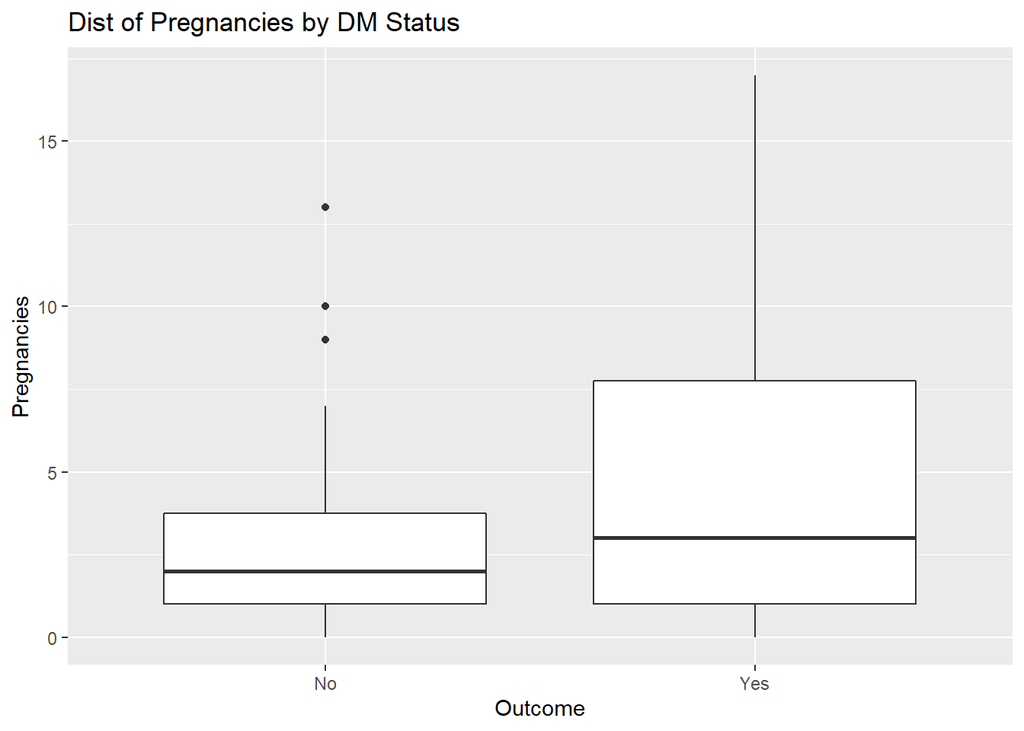

```r
##side by side boxplots
ggplot(train, aes(x=Outcome, y=Pregnancies))+
geom_boxplot()+
labs(title="Dist of Pregnancies by DM Status")
```

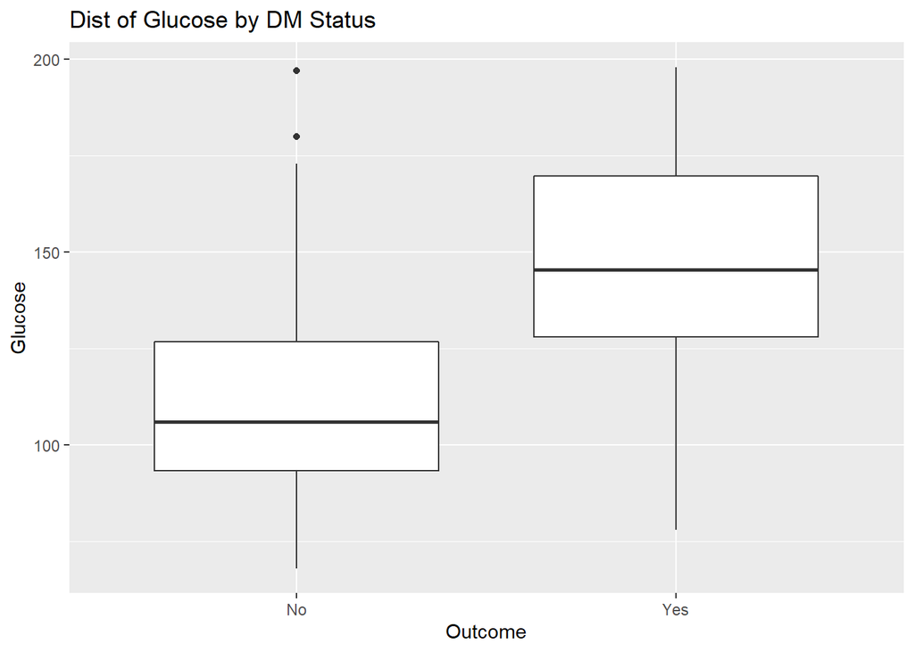

```r
ggplot(train, aes(x=Outcome, y=Glucose))+
geom_boxplot()+
labs(title="Dist of Glucose by DM Status")
```

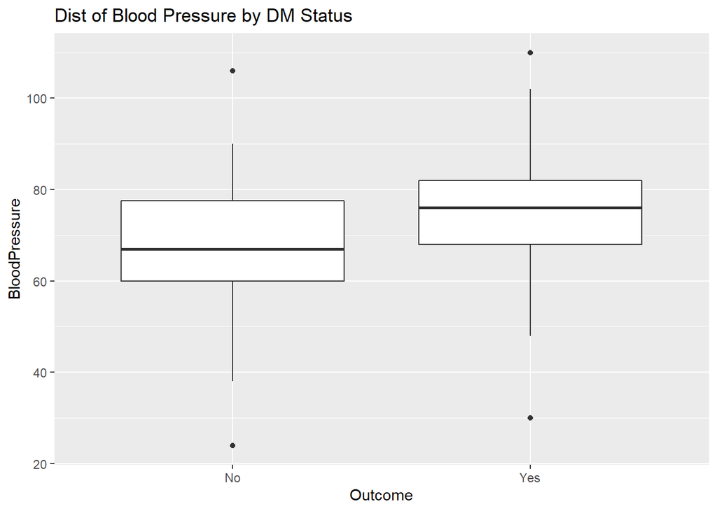

```r
ggplot(train, aes(x=Outcome, y=BloodPressure))+
geom_boxplot()+
labs(title="Dist of Blood Pressure by DM Status")
```

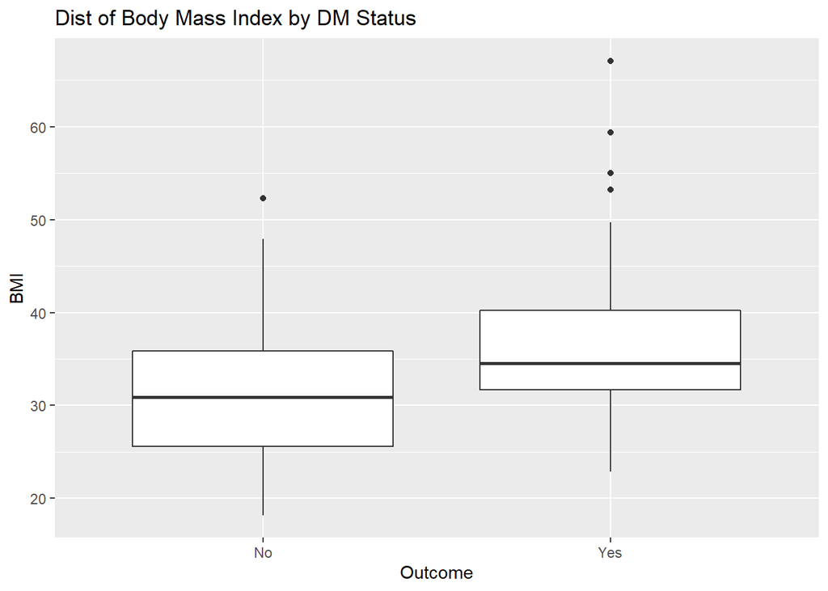

```r
ggplot(train, aes(x=Outcome, y=BMI))+
geom_boxplot()+
labs(title="Dist of Body Mass Index by DM Status")
```

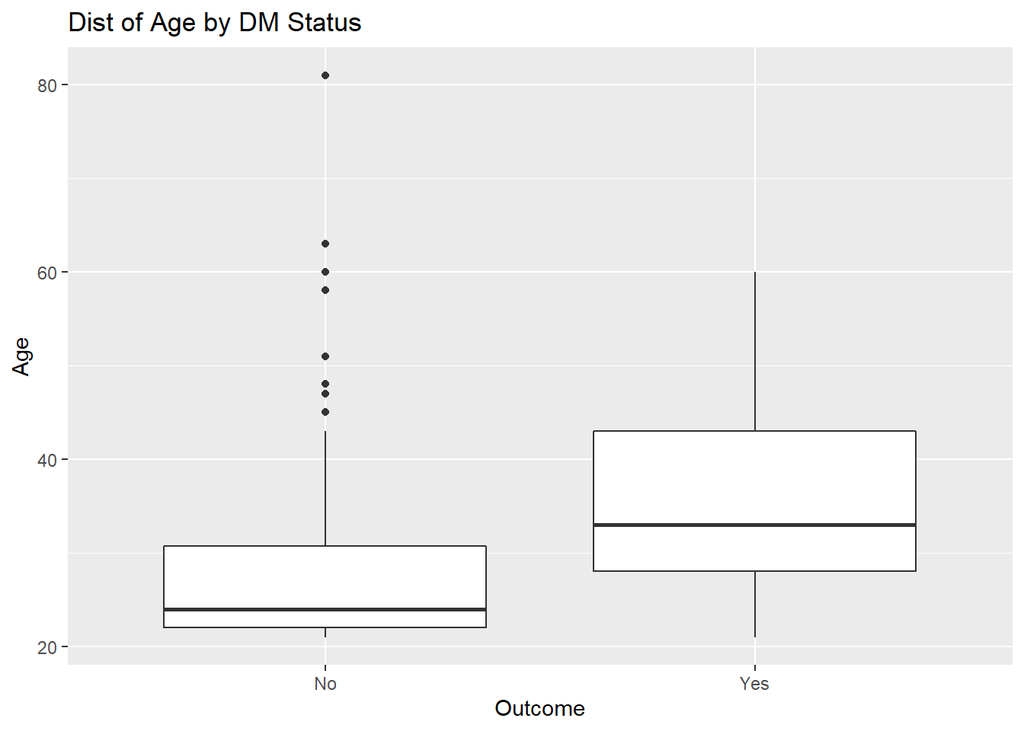

```r
ggplot(train, aes(x=Outcome, y=Age))+
geom_boxplot()+
labs(title="Dist of Age by DM Status")
```

I created density plots. Focusing on the more traditional risk factors, those with a higher BMI and older adults were more likely to be diagnosed with DM.

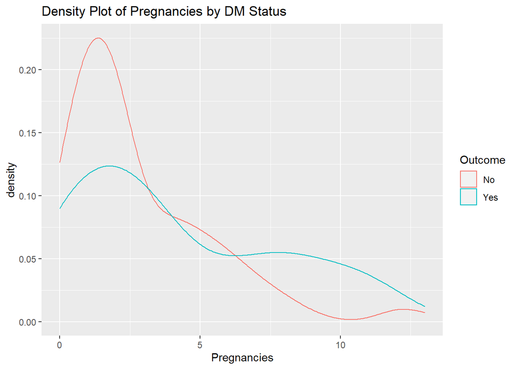

```r
##density plots
ggplot(test,aes(x=Pregnancies, color=Outcome))+
geom_density()+
labs(title="Density Plot of Pregnancies by DM Status")
```

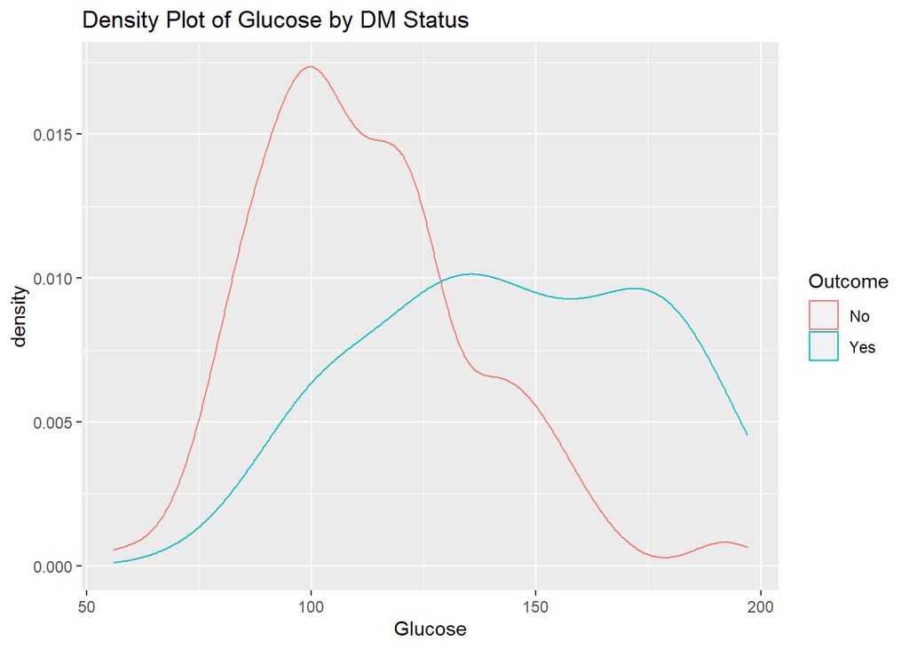

```r
##density plots
ggplot(test,aes(x=Glucose, color=Outcome))+
geom_density()+
labs(title="Density Plot of Glucose by DM Status")
```

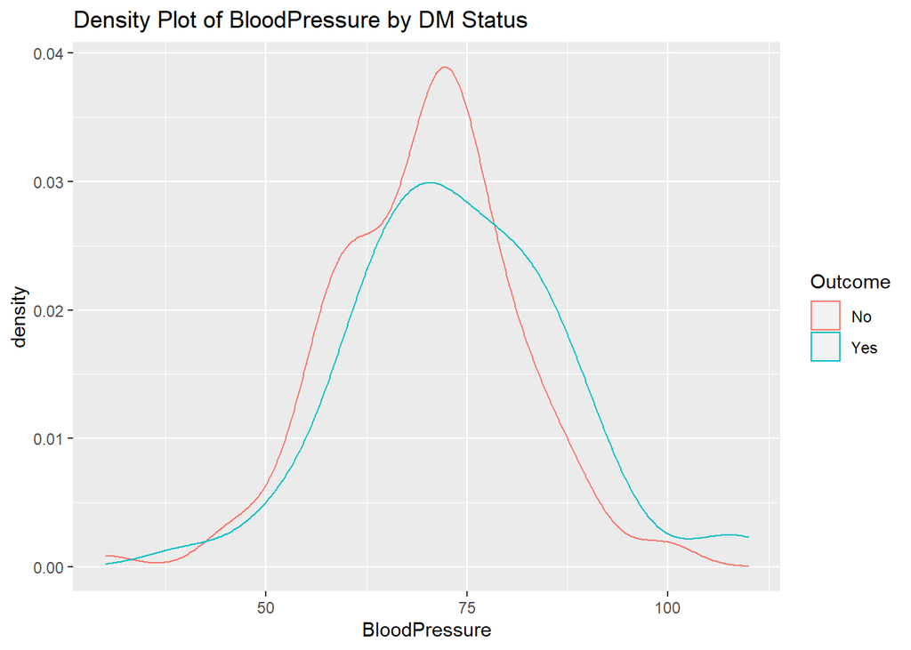

```r
##density plots
ggplot(test,aes(x=BloodPressure, color=Outcome))+
geom_density()+
labs(title="Density Plot of BloodPressure by DM Status")
```

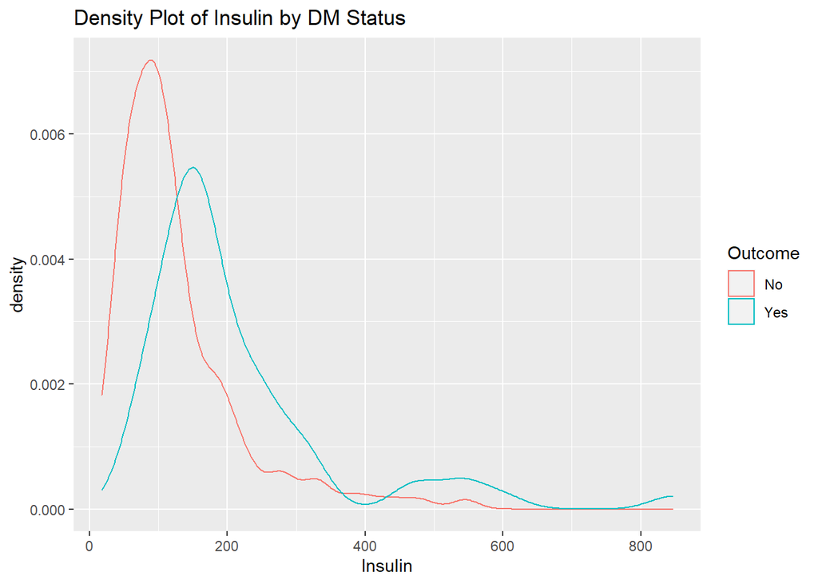

```r
##density plots
ggplot(test,aes(x=Insulin, color=Outcome))+
geom_density()+
labs(title="Density Plot of Insulin by DM Status")
```

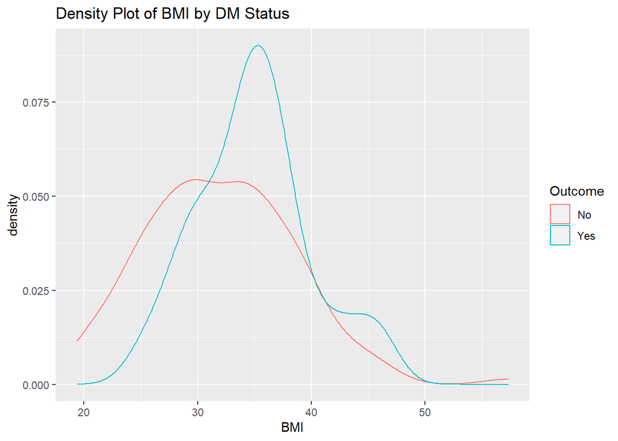

```r
##density plots
ggplot(test,aes(x=BMI, color=Outcome))+
geom_density()+
labs(title="Density Plot of BMI by DM Status")
```

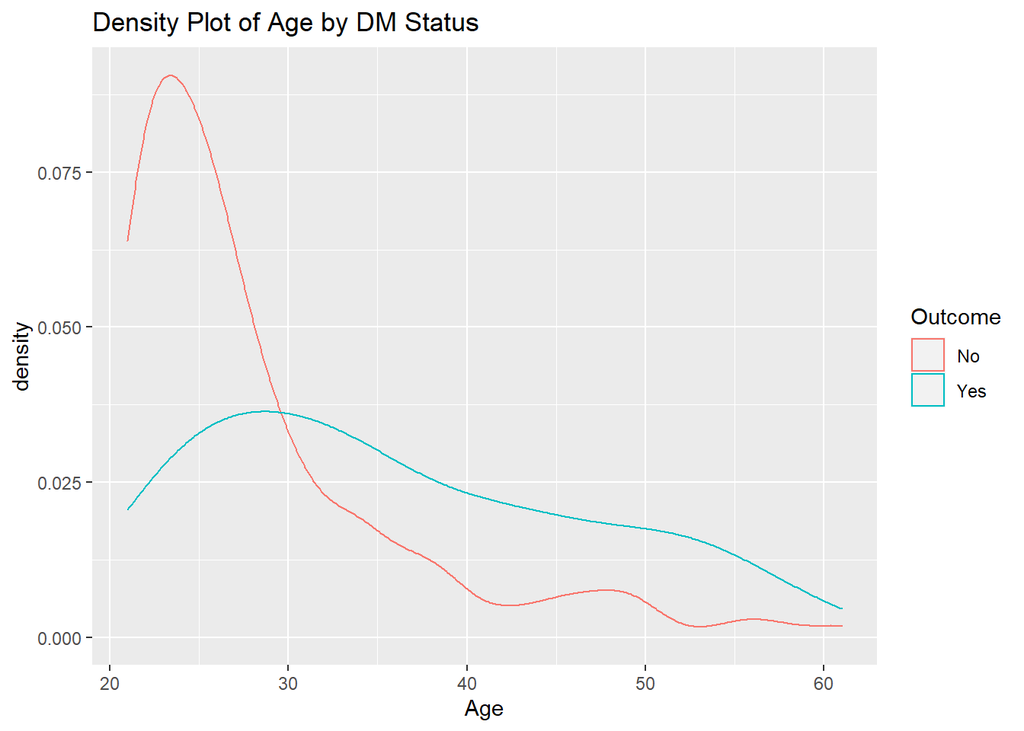

```r
##density plots
ggplot(test,aes(x=Age, color=Outcome))+
geom_density()+
labs(title="Density Plot of Age by DM Status")
```

Fitting the logistic regression. Ho: B1 = B2 = B3 = B4 = B5 = B6 = B7 = B8 = 0 Ha: At least one of the coefficients does not equal 0.

Only glucose and BMI are statistically significant within the model. Based on this output, I will fit an additional logistic regression using only those two predictors and compare the two models.

```r
full<-glm(Outcome~Age+Pregnancies+Glucose+BloodPressure+Insulin+DiabetesPedigreeFunction+SkinThickness+BMI, family=binomial, data=train)
summary(full)
```

```
##
## Call:
## glm(formula = Outcome ~ Age + Pregnancies + Glucose + BloodPressure +
##     Insulin + DiabetesPedigreeFunction + SkinThickness + BMI,
##     family = binomial, data = train)
##
## Deviance Residuals:
##     Min       1Q   Median       3Q      Max
## -2.3299  -0.6365  -0.3587   0.6312   2.4593
##
## Coefficients:
##                           Estimate Std. Error z value Pr(>|z|)
## (Intercept)              -9.640147   1.640116  -5.878 4.16e-09 ***
## Age                       0.025005   0.024542   1.019   0.3083
## Pregnancies               0.099708   0.075162   1.327   0.1846
## Glucose                   0.043501   0.008713   4.993 5.96e-07 ***
## BloodPressure            -0.004069   0.016277  -0.250   0.8026
## Insulin                  -0.002677   0.001902  -1.407   0.1594
## DiabetesPedigreeFunction  0.487525   0.599129   0.814   0.4158
## SkinThickness             0.011939   0.023972   0.498   0.6185
## BMI                       0.072893   0.036499   1.997   0.0458 *
## ---
## Signif. codes:  0 '***' 0.001 '**' 0.01 '*' 0.05 '.' 0.1 ' ' 1
##
## (Dispersion parameter for binomial family taken to be 1)
##
##     Null deviance: 255.49  on 195  degrees of freedom
## Residual deviance: 174.08  on 187  degrees of freedom
## AIC: 192.08
##
## Number of Fisher Scoring iterations: 5
```

Here is the reduced model.

```r
reduced<-glm(Outcome~Glucose+BMI, family=binomial, data=train)
summary(reduced)
```

```
##
## Call:
## glm(formula = Outcome ~ Glucose + BMI, family = binomial, data = train)
##
## Deviance Residuals:
##     Min       1Q   Median       3Q      Max
## -2.2579  -0.7554  -0.4021   0.7076   2.3939
##
## Coefficients:
##              Estimate Std. Error z value Pr(>|z|)
## (Intercept) -8.040216   1.224641  -6.565 5.19e-11 ***
## Glucose      0.041202   0.006902   5.970 2.38e-09 ***
## BMI          0.065151   0.025492   2.556   0.0106 *
## ---
## Signif. codes:  0 '***' 0.001 '**' 0.01 '*' 0.05 '.' 0.1 ' ' 1
##
## (Dispersion parameter for binomial family taken to be 1)
##
##     Null deviance: 255.49  on 195  degrees of freedom
## Residual deviance: 187.07  on 193  degrees of freedom
## AIC: 193.07
##
## Number of Fisher Scoring iterations: 4
```

Next I will compare the model with 2 coefficients to the model with 8 coefficients.I THINK I use 6. Not entirely sure on that one. I am going to pause here for group input.

```r
##test if additional predictors have coefficients equal to 0
##test stat
TS<-reduced$deviance-full$deviance
##pvalue
1-pchisq(TS,6)
```

```
## [1] 0.04322491
```